# Interactive Visualization With Plotly - Seaborn - 1

One should look for what is and not what he thinks should be. (Albert Einstein)

# Seaborn: Topic introduction

In this part of the course, we will cover the following concepts:

- Introduce seaborn package and it’s capabilities
- Organize and visualize data with seaborn

# Warm-up

- Have you ever wondered, “how do eggs get their shape?”
- Take a look at this Science Mag website with cool interactive visualizations [here](https://vis.sciencemag.org/eggs/)
  - Did you find the visualizations effective? What was the most interesting?

# Module completion checklist

| Objective | Complete |
| --- | --- |
| Introduce Seaborn plotting library and create univariate plots |  |
| Plot bivariate charts, heatmaps and format plots in Seaborn |  |

# What is `seaborn`?

- seaborn is a python data visualization library based on [matplotlib](https://matplotlib.org/)
- It provides a high-level interface for drawing attractive and informative statistical graphics
- It integrates closely with pandas dataframes
- It has a variety of sample datasets available for experimenting with plots
- It uses the `rcParams` structure to control graph elements, like matplotlib
- [Click here](https://seaborn.pydata.org/) to learn more about `seaborn`

[figure not shown]

# What can you do with `seaborn`?

- Like matplotlib, `seaborn` has a beautiful gallery of different types of plots
- Check out the `seaborn` gallery [here](https://seaborn.pydata.org/examples/index.html)
- Examples include:
  - Univariate plots: Histograms, Box plots, Bar charts
  - Bivariate plots: Scatter plots, Line plots, Residual plots
  - Heatmaps

# Introduce the penguins dataset

- This is an `seaborn` inbuilt dataset
- The data was collected and made available by Dr. Kristen Gorman and the Palmer Station, Antarctica LTER, a member of the Long Term Ecological Research Network

# Data description of penguin dataset

- Let’s look at the detailed data description of penguin dataset
  - species: a factor denoting penguin species (Adélie, Chinstrap and Gentoo)
  - island: a factor denoting island in Palmer Archipelago, Antarctica (Biscoe, Dream or Torgersen)
  - bill_length_mm: a number denoting bill length (millimeters)
  - bill_depth_mm: a number denoting bill depth (millimeters)
  - flipper_length_mm: an integer denoting flipper length (millimeters)
  - body_mass_g: an integer denoting body mass (grams)
  - sex: a factor denoting penguin sex (female, male)

# Loading the dataset and libraries

- Let’s import required libraries

```python
# import the libraries
import seaborn as sns
from matplotlib import pyplot as plt
```

- Load the penguin dataset from `seaborn`

```python
# Load the dataset
penguins = sns.load_dataset("penguins")

# Top 5 entries of dataset
penguins.head()
```

```
  species     island  bill_length_mm  ...  flipper_length_mm  body_mass_g     sex
0  Adelie  Torgersen            39.1  ...              181.0       3750.0    Male
1  Adelie  Torgersen            39.5  ...              186.0       3800.0  Female
2  Adelie  Torgersen            40.3  ...              195.0       3250.0  Female
3  Adelie  Torgersen             NaN  ...                NaN          NaN     NaN
4  Adelie  Torgersen            36.7  ...              193.0       3450.0  Female

[5 rows x 7 columns]
```

# Data preprocessing

- Let’s check for NA’s in penguin dataset and remove them

```python
# Check for null values
penguins.isna().sum()
```

```
species               0
island                0
bill_length_mm        2
bill_depth_mm         2
flipper_length_mm     2
body_mass_g           2
sex                  11
dtype: int64
```

- Drop the NA values

```python
# Drop NA's and reassign clean data
penguins = penguins.dropna()
```

- Now our data is ready, let’s create plots out of it using `seaborn`

# Univariate plots

- Univariate plots are used to visualize distribution of a single variable
- They are used primarily in the initial stages of EDA to learn more about individual variables in our data
- They are also used in combination with other univariate plots to compare data distributions of different variables
- Univariate plots include the following popular graphs: boxplot, histogram, density curve, dot plot, QQ plot, and bar plot
- Different univariate plots

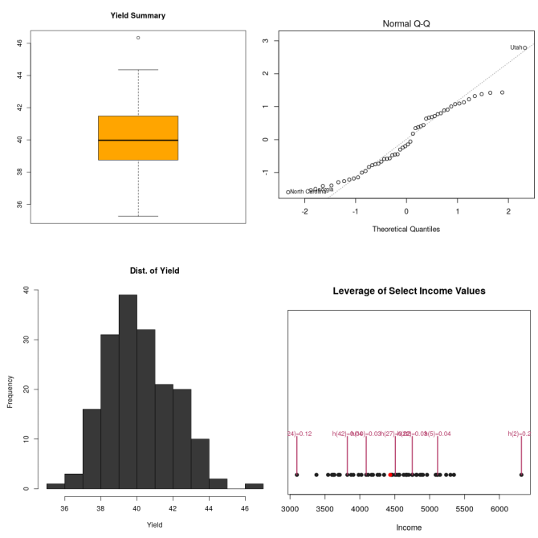

# Univariate plots: histogram

- A histogram represents the distribution of numerical data
  - The height of each bar has been calculated as the number of observations in that range
  - `histplot()` produces a basic histogram of any *numeric* variable

# Plot a histogram

- Let’s create a histogram to visualize the penguin data
- Here we will look at the distribution of the body mass in grams of penguins

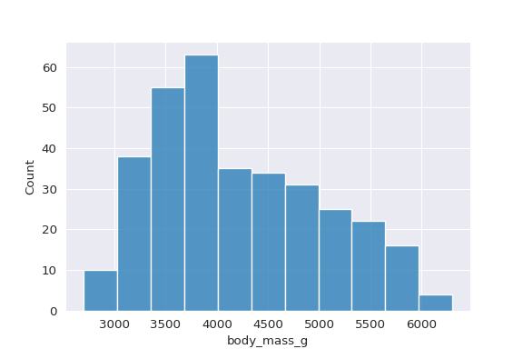

```python
plt.figure(figsize=(6,4))      #<- set the figure size

# Create a simple histogram
sns.histplot(data = penguins,     #<- dataset
        x = "body_mass_g")        #<- x_axis variable
```

# Plot a layered histogram

- We have a visual of body mass of all penguins, but what if we want to compare the distributions by species?
- We can change this simple histogram into a layered histogram by just adding two parameters, `hue` and `palette`
- `hue` describes the grouping mechanism for our histogram, and `palette` tells Seaborn what colors to use
- You can see the list of possible palettes [here](https://seaborn.pydata.org/tutorial/color_palettes.html)

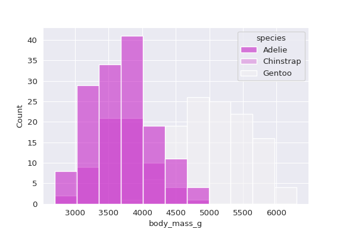

```python
plt.figure(figsize=(6,4))     #<- set the figure size

sns.histplot(data = penguins,     #<- set data
      x = "body_mass_g",          #<- set x variable
      hue = "species",            #<- grouping parameter
      palette = "light:m_r")      #<- set color
```

# Univariate plots: box plot

- Histograms aren’t the only type of plot used to illustrate the distribution of a variable. We can also use box plots.
- Instead of showing the shape of the distribution, box plots show the quartiles of your data and unlike a histogram, box plots show outliers in our data
- We will use the same `penguins` dataset and `body_mass_g` variable:

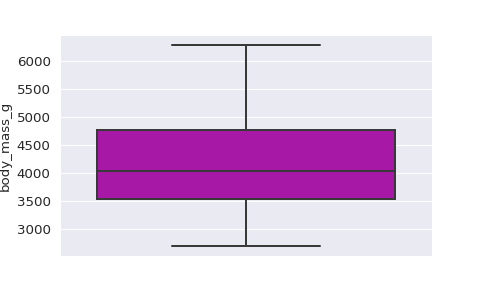

```python
plt.figure(figsize=(5,3))     #<- set the figure size

# Create a simple boxplot
sns.boxplot(data = penguins,      #<- set data
        y = "body_mass_g",        #<- set y variable
        palette = ["m"])          #<- set color
```

# Plot a box plot

- Like a histogram we can compare distributions of different variables on a single box plot by adding a single parameter `x` and set the appropriate color palette using `palette` parameter

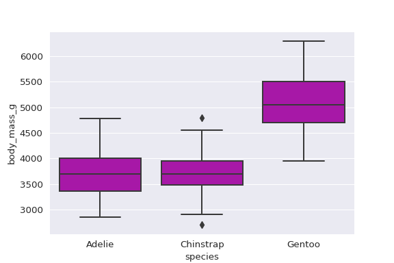

```python
plt.figure(figsize=(6,4))    #<- set the figure size
sns.boxplot(data = penguins,    #<- set data
        x = "species",          #<- set x variable
        y = "body_mass_g",      #<- set y variable
        palette = ["m"])        #<- set color
```

# Univariate plots: bar plot

- The final type of univariate plot we are going to discuss is a bar plot
- The bar plot is used to compare categories within a dataset

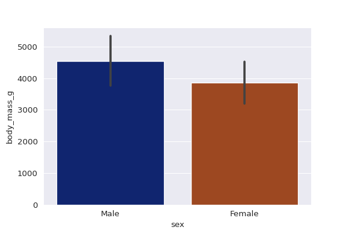

```python
plt.figure(figsize=(6,4))       #<- set the figure size

# Create a barplot
sns.barplot(data = penguins,     #<- set the data
        x = "sex",               #<- set x variable
        y = "body_mass_g",       #<- set y variable
        ci = "sd",
        palette = "dark")        #<- set color
```

# Plot a bar plot

- Like box plots and histograms, bar plots can compare groups by adding an extra parameter, `hue`

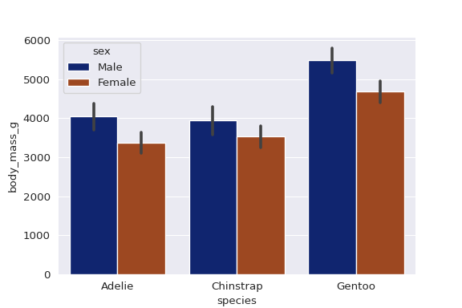

```python
plt.figure(figsize=(6,4))         #<- set the figure size
sns.barplot(data = penguins,      #<- set the data
        x = "species",            #<- set x variable
        y = "body_mass_g",        #<- set y variable
        hue = "sex",ci="sd",      #<- set grouping variable
        palette = "dark")         #<- set color
```

# Module completion checklist

| Objective | Complete |
| --- | --- |
| Introduce Seaborn plotting library and create univariate plots | **✔** |
| Plot bivariate charts, heatmaps and format plots in Seaborn |  |

# Bivariate plots

- Bivariate plots are used to visualize data distribution and relationships between **two variables**
- They are used to a great extent throughout different stages of EDA to learn more about how **one variable relates to another**
- They are also used in combination with other bivariate plots to compare relationships between **different pairs of variables**
- Bivariate plots include `scatterplots` and `line graphs`

# Bivariate plots: scatter plot

- Scatter plots are an excellent way to see the relationship between two variables

[figure not shown]

```python
plt.figure(figsize=(6,4))         #<- set the figure size

# Create a scatterplot
sns.scatterplot(data = penguins,       #<- set the data
        x = "bill_length_mm",          #<- set x variable
        y = "flipper_length_mm",        #<- set y variable
        linewidth = 0)                 #<- set line width
```

# Bivariate plots: line plot

- After we see a linear relationship between two variables, we may want to plot that relationship, that is where a line plot comes in

```python
plt.figure(figsize=(5,4))      #<- set the figure size

sns.lmplot(data = penguins,          #<- set the data
        x = "bill_length_mm",        #<- set x variable
        y = "flipper_length_mm",     #<- set y variable
        fit_reg = True)
```

[output not shown]

```
<seaborn.axisgrid.FacetGrid object at 0x7fb43f0c1690>
```

# Bivariate plots: residual plot

- One way we can decide if there is a linear relationship between those two variables is to look at a plot of the residuals
- Seaborn allows you to plot those residuals with one simple line of code

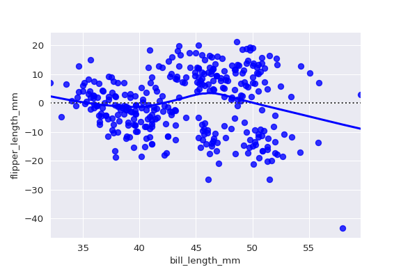

```python
plt.figure(figsize=(6,4))          #<- set the figure size
sns.residplot(data = penguins,
        x = 'bill_length_mm',               #<- set x variable
        y = 'flipper_length_mm',            #<- set y variable
        lowess = True,
        color="b")
```

# Multivariate plots: Heatmaps

- One way we can check to see what variables we might want to use in a model is to check the correlations of those variables
- An easy way to see those correlations is a heatmap
- Which variables are correlated with each other?

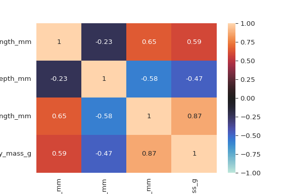

```python
plt.figure(figsize=(6,4))            #<- set the figure size
sns.heatmap(penguins.corr(),         #<- set the data to find out the correlation
        vmin = -1,
        vmax = 1,
        center = 0,
        annot = True)
```

# Format plots in seaborn

- Our Seaborn plots come out readable if variables are named well
- What if we haven’t named them well or want to change the names on the axes and title of our plot?
- `seaborn` allows easy formatting of things like the title or the axes labels using the `set` function

# Format plots in seaborn (cont’d)

```python
plt.figure(figsize=(5,4))            #<- set the figure size
g = sns.lmplot(data = penguins,
        x = "bill_length_mm",                   #<- set x variable
        y = "flipper_length_mm",                #<- set x variable
        height = 4,                             #<- set the height
        fit_reg = True)
g.set(title = 'Bill Length versus Flipper Length',           #<- set the title
        xlabel = 'Bill Length (mm)',                         #<- set label for x variable
        ylabel = 'Flipper Length (mm)')                      #<- set label for y variable
```

[output not shown]

```
<seaborn.axisgrid.FacetGrid object at 0x7fb43f09b710>
```

# Knowledge check

# Exercise

You are now ready to try tasks 1-10 in the Exercise for this topic

# Module completion checklist

| Objective | Complete |
| --- | --- |
| Introduce Seaborn plotting library and describe univariate plots in Seaborn | **✔** |
| Describe bivariate plots and heatmaps and format plots in Seaborn | **✔** |

# Seaborn: Topic summary

In this part of the course, we have covered:

- Introduce seaborn package and it’s capabilities
- Organize and visualize data with seaborn

# Congratulations on completing this module!